# CF duration analysis - whole audio version

Thejasvi Beleyur

7/6/2021

This is a follow up analysis to delve deeper into the apparent decrease in CF duration

This notebook will detail the use of bayesian linear models and mixed models to quantify the difference between single and multi-bat call CF duration only.

```r
library(arm)
library(coda)
library(lme4)
library(stringi)
library(stringr)
set.seed(82319)
d <- read.csv('../verified_cf_detections.csv')
# create a single/multi-bat categorical variable
d['multi_bat'] <- factor(d['num_bats']>1)
d['annot_id'] <- stri_sub(d$audio_file,28,-4)
d['annot_id'] <- str_replace_all(d$annot_id, '21502300','2123')
# sort the dataset by time first
time_ordering <- stri_order(d$annot_id,numeric=TRUE)
d_tordered <- d[time_ordering,]
# - is there an influence of the recording hour?
split.and.join <- function(x){
  splitx <- str_split(x,'_')
  jointx <- paste(splitx[[1]][1],'_',splitx[[1]][2],sep='')
  jointx}
d_tordered$rechour <- sapply(d_tordered$annot_id,split.and.join)

# also scale up some of the measurements into more meaningful units
# -- here we'll multiply by 10^3 to convert s to ms
d_tordered$duration <- d_tordered$duration*10^3

num_post <- 5000
# convenience function
get.hpd <- function(x,prange=0.95){HPDinterval(as.mcmc(x),prob=prange)}

get.map.coi <- function(x){c(mean(x), get.hpd(x))}
```

## Quick data plotting

Let’s plot our data first to see if everything about it is okay.

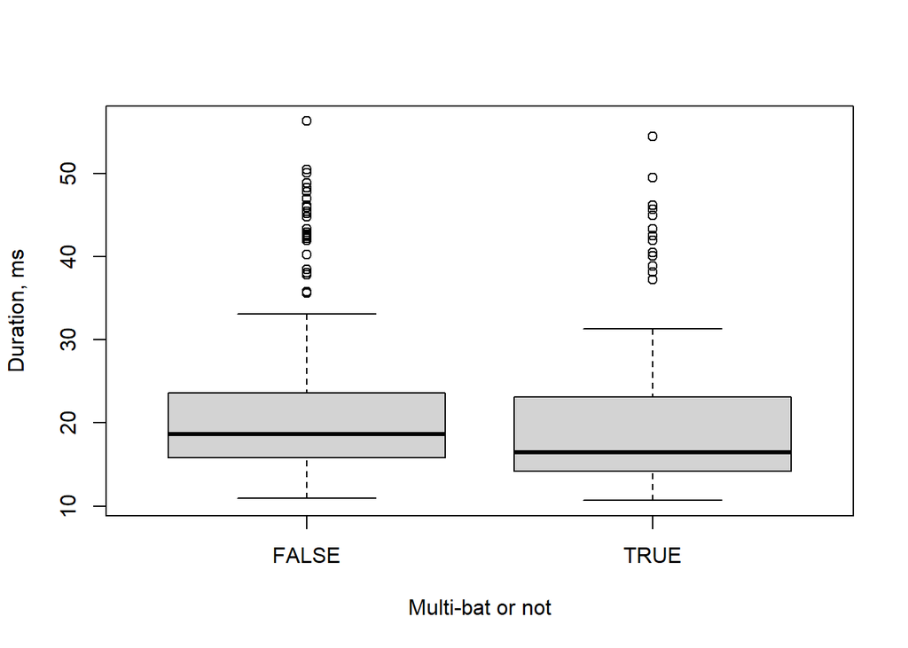

```r
boxplot(duration~as.factor(multi_bat), data=d_tordered, ylab='Duration, ms', xlab='Multi-bat or not')
```

Just looking at the data

## Linear model: starting simple

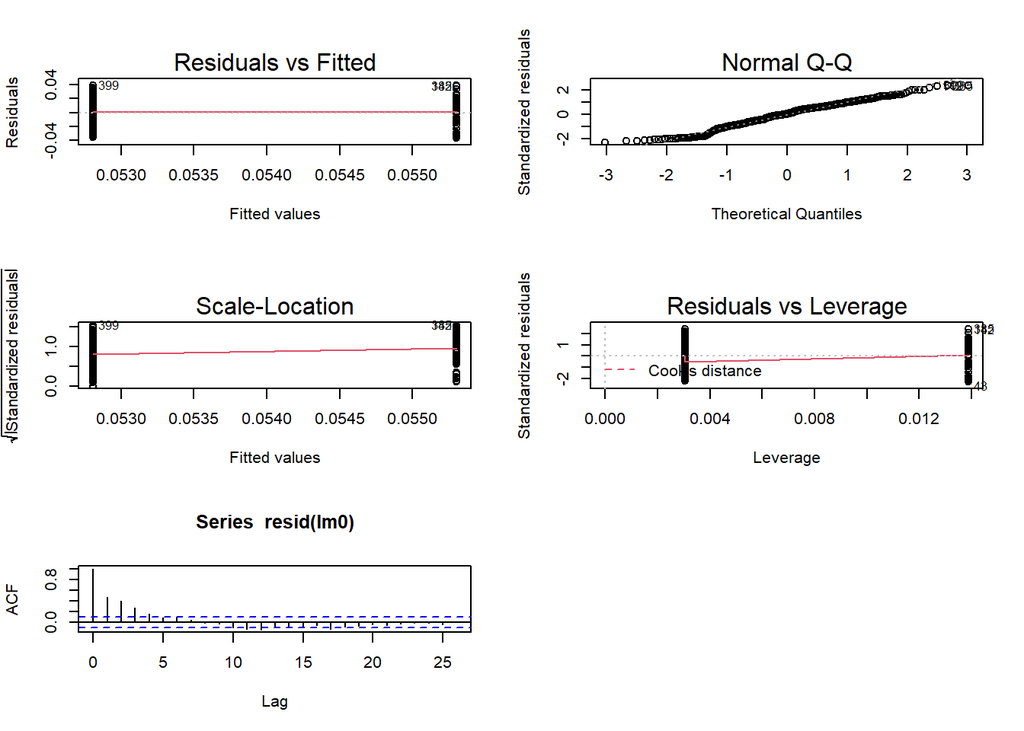

```r
d_tordered$invdurn <- d_tordered$duration^-1
lm0 <- lm(invdurn~as.factor(multi_bat), data=d_tordered)


par(mfrow=c(3,2))
plot(lm0)
acf(resid(lm0))
```

The 1/y transform seems to work best in making the model fit the normal assumptions. I also tried the square-root and log10 transforms - but they didn’t work as well.

We see there is some autocorrelation in the residuals - which is kind of expected since when there are multiple calls from the same audio file, we can expect that the CF durations are also similar. This tells us we need to include annotation ID as a factor in a mixed effects model.

## Linear mixed-model: accounting for correlations within each audio clip

Let’s build a LMM with the annotation-ID (recording ID) and recording hour as the random intercepts, and the group size (single/multi) as a fixed effect. There can be multiple CF duration measurements from the same recording, and the same bats may be seen within the span of an hour, so this is likely to be the main source of correlation in the dataset.

*Note*: `rechour` added as a random intercept on 2021-07-30, and the `rechour` as a fixed effect analysis aren’t reported in the paper anymore.

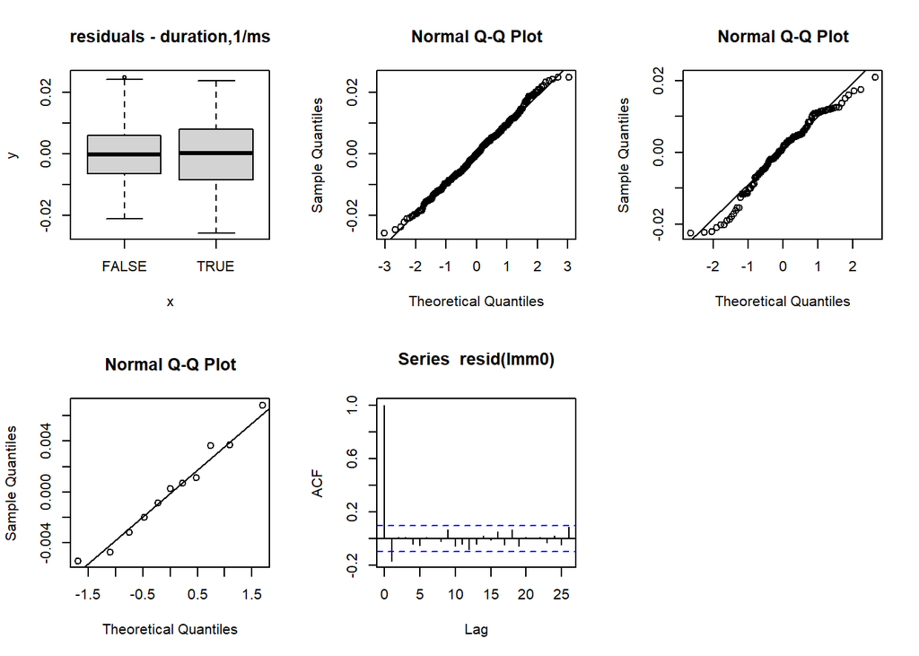

```r
lmm0 <- lmer(invdurn~as.factor(multi_bat)+(1|annot_id) +(1|rechour), data=d_tordered)


par(mfrow=c(2,3))
# check residuals vs multi_bat
plot(d_tordered$multi_bat,resid(lmm0),main='residuals - duration,1/ms')
# do residuals match the normal distbn assumption - qqplot
qqnorm(resid(lmm0));qqline(resid(lmm0))
# do random effects match normal distbn assumption - qqplot
qqnorm(ranef(lmm0)$annot_id$`(Intercept)`);qqline(ranef(lmm0)$annot_id$`(Intercept)`,main='random effects')
# do random effects match normal distbn assumption - qqplot
qqnorm(ranef(lmm0)$rechour$`(Intercept)`);qqline(ranef(lmm0)$rechour$`(Intercept)`,main='random effects')
# check crudely for autocorrelation of residuals
acf(resid(lmm0))
```

The assumptions of the LMM seem to be met fairly okay - though not perfectly. Now, let’s proceed to run simulations to and estimate parameter values.

```r
cfdurn.sim <- sim(lmm0, n.sim=num_post)
cfdurn.fixefs.hpd <- round(apply(fixef(cfdurn.sim),2,get.hpd),2)
single_cfdurn <- 1/fixef(cfdurn.sim)[,1]
multi_cfdurn <- 1/(fixef(cfdurn.sim)[,1]+fixef(cfdurn.sim)[,2])

# difference in ms:
cfdurn.diff <- multi_cfdurn - single_cfdurn
cfdurn.diff.mapcoi <- get.map.coi(cfdurn.diff)

# Mean MAP and CoI
cfdurn.single.mapcoi <- get.map.coi(single_cfdurn)
cfdurn.multi.mapcoi <- get.map.coi(multi_cfdurn)

cfdurn.rel.increase <- multi_cfdurn/single_cfdurn
# ratio MAP and CoI
cfdurn.rel.mapcoi <- get.map.coi(cfdurn.rel.increase)


single.cfdurn.hpd <- round(get.hpd(single_cfdurn),2)
multi.cfdurn.hpd <- round(get.hpd(multi_cfdurn),2)
cfdurn.rel.hpd <- round(get.hpd(cfdurn.rel.increase),2)
```

### Round 2 analysis (2021-07-14) (not used anymore)

These are my attempts at checking to see if the small peak in the residual autocorrelation is perhaps because I didn’t consider an additional variable (eg. recording hour). Even though I don’t have reason to, I also see that the recording hour itself may have systematic effects because the same bat flew repeatedly within a period of time. Broadly speaking, the ‘null’ result from the primary analysis is not surprising.

```r
# lmm.post <- lmer(invdurn~as.factor(multi_bat)+(1|annot_id)+rechour, data=d_tordered)
#
#
# par(mfrow=c(3,2))
# # check residuals vs multi_bat
# plot(d_tordered$multi_bat,resid(lmm.post),main='residuals - duration,1/ms')
# # do residuals match the normal distbn assumption - qqplot
# qqnorm(resid(lmm.post));qqline(resid(lmm.post))
# # do random effects match normal distbn assumption - qqplot
# qqnorm(ranef(lmm.post)$annot_id$`(Intercept)`);qqline(ranef(lmm.post)$annot_id$`(Intercept)`,main='random effects')
# # check crudely for autocorrelation of residuals
# acf(resid(lmm.post))
# # check if the residuals are similar across recording hours
# boxplot(resid(lmm.post)~d_tordered$rechour)
```

```r
#
#
# cfdurn.sim.post <- sim(lmm.post, n.sim=num_post)
# cfdurn.fixefs.hpd.post <- round(apply(fixef(cfdurn.sim.post),2,get.hpd),2)
# single_cfdurn.post <- 1/fixef(cfdurn.sim.post)[,1]
# multi_cfdurn.post <- 1/(fixef(cfdurn.sim.post)[,1]+fixef(cfdurn.sim.post)[,2])
#
# cfdurn.rel.increase.post <- multi_cfdurn.post/single_cfdurn.post
#
#
# single.cfdurn.hpd.post <- round(get.hpd(single_cfdurn.post),2)
# multi.cfdurn.hpd.post <- round(get.hpd(multi_cfdurn.post),2)
# cfdurn.rel.hpd.post <- round(get.hpd(cfdurn.rel.increase.post),2)
```

### Final summary

The final results do not seem to support a decrease in cF duration in groups, as suggested by the individual call analysis. The multi-call CF duration analysis is more robust because of the increased sample sizes - and so I’d side more with these results.

```r
df <- rbind(cfdurn.diff.mapcoi, cfdurn.rel.mapcoi, cfdurn.single.mapcoi, cfdurn.multi.mapcoi)
row.names(df) <- c('durn-difference','durn-ratio','single','multi')
colnames(df)<- c('MAP','lower-95pcHPD', 'upper-95pcHPD')
write.csv(df, 'cf_duration_change_summary.csv')
```